# Kaplan Meier

Jana Fischer

# Read in survival data

```r
library(data.table)
library(survival)
library(RColorBrewer)
library(ggplot2)
library(broom)

surv_dat = fread('../../../data/survival_example_data.csv',header = TRUE)
head(surv_dat)
```

```
##    PID grade            Patientstatus OSmonth DFSmonth
## 1: 257     3                    alive     154       98
## 2:   7     3                    death      37       37
## 3: 166     3 death by primary disease      37       35
## 4: 238     1                    alive     233      140
## 5:  68     1                    alive     169      169
## 6:  72     3                    alive     186      186
```

Column description:  
PID: patient identifier  
grade: tumor pathology grade  
OSmonth: overall suvival from time of diagnosis [months]  
DFSmonth: disease free survival from time of diagnosis [months]  
Patientstatus: life/death status  
“death by primary disease” = death due to disease  
“death” = disease unrelated death  
“alive” = alive at given survival time  
“alive w metastases” = alive with metasatses at given survival time

# Prepare data for Kaplan Meier survival curves

Survival data is censored when the event has not yet occurred for a patient at a given time or the patient is lost to follow-up during the study. In Kaplan Meier survival curves censored patients are indicated by a cross on the curve. A more detailed explanation can be found here: http://www.sthda.com/english/wiki/survival-analysis-basics#censoring

```r
# Censoring for overall survival (1 = event (death due to disease), 0 = censored)
surv_dat[,censoringOS := 0]
surv_dat[Patientstatus == 'death by primary disease',censoringOS := 1]

# Censoring for disease free survival (1 = event (recurrence), 0 = censored)
surv_dat[ ,censoringDFS := 0]
surv_dat[ Patientstatus == 'alive w metastases',censoringDFS := 1]
surv_dat[ OSmonth > DFSmonth, censoringDFS := 1]


# Build the standard survival object with the Surv function from the package
# "survival". A plus behind the survival time inicates censoring in the survival object.
SurvObj_OS <- Surv(surv_dat$OSmonth, surv_dat$censoringOS)
SurvObj_DFS <- Surv(surv_dat$DFSmonth, surv_dat$censoringDFS)
```

# Compute Kaplan Meier estimates

Use the survfit function from the “survival” package in order to produce the Kaplan Meier estimates of probability of survival over time.

```r
# Compute the survival curve across all patients in the survival object.
# Here we use overall suvrival. For disease free just replace the SurvObj_OS
# with SurvObj_DFS.
KM_all <- survfit(SurvObj_OS ~ 1)

# Compute survival curves for different groups of patients (here grade).
surv_dat[,grade := as.factor(grade)]
KM_groups <- survfit(SurvObj_OS ~ surv_dat$grade)
```

# Plot survival curves overlaid in one panel

Use the plot function from the survival package to visualize the KM survival curves. Alternatively, one could use the “ggfortify” package providing the ggplot2::autoplot function.

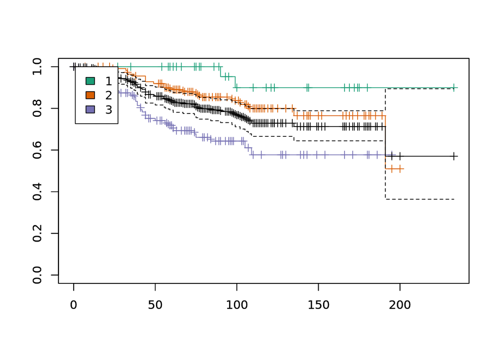

```r
# Color map for plotting
cols = brewer.pal(3,"Dark2")

# All patinets survival curve: black, grade survival curves: color (CIs for strata not plotted)
plot(KM_groups,mark.time = T,col = cols[as.numeric(levels(surv_dat$grade))],conf.int = F)
par(new=TRUE)
plot(KM_all,mark.time = T,col = "black",conf.int = T)
legend(1,1,levels(surv_dat$grade),cols[as.numeric(levels(surv_dat$grade))])
```

# Plot survival curves in individual panels

Loop through grades to plot each in separate panel (plot CIs) and plot curve across all patients as a reference in each panel.

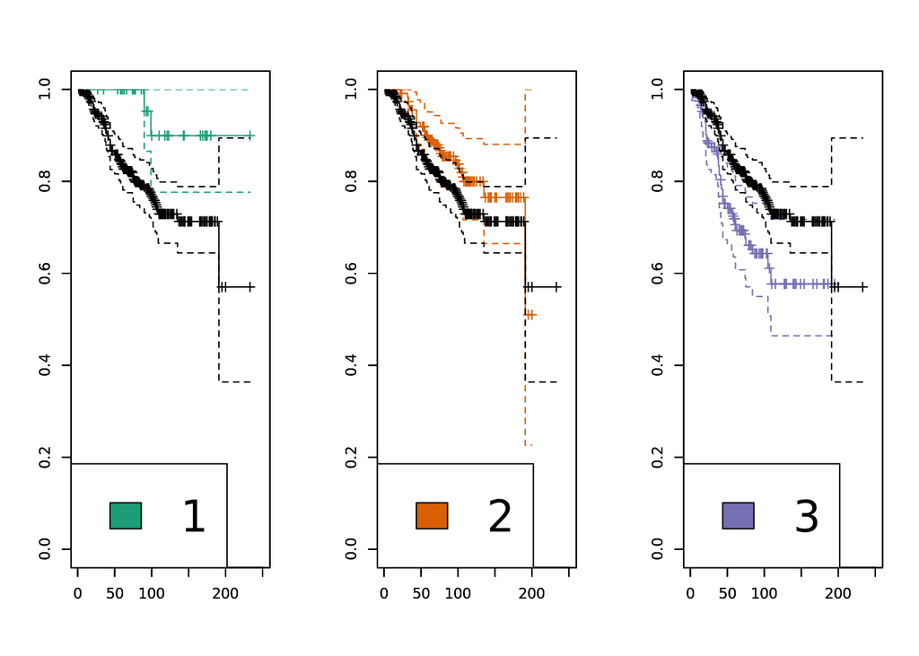

```r
par(mfrow=c(1,3))
for (i in levels(surv_dat$grade)){

  # Data corresponding to current grade
  cur_dat = subset(surv_dat, surv_dat$grade == i)
  SurvObj_cur <- Surv(cur_dat$OSmonth, cur_dat$censoringOS)
  KM_cur <- survfit(SurvObj_cur ~ 1)

  # Current grade group in color
  plot(KM_cur,mark.time = T,col = cols[as.numeric(i)],xlim=range(1:250),conf.int = T)
  par(new=TRUE)
  # All patients curve in black
  plot(KM_all,mark.time = T,col = "black",xlim=range(1:250),conf.int = T)
  legend("bottomleft",1,i,cols[as.numeric(i)], cex=3)
}
```

# Plot survival curves with ggplot2

Alternatively, use tidy from the broom package to summarize and format the output of survfit for direct use with ggplot2

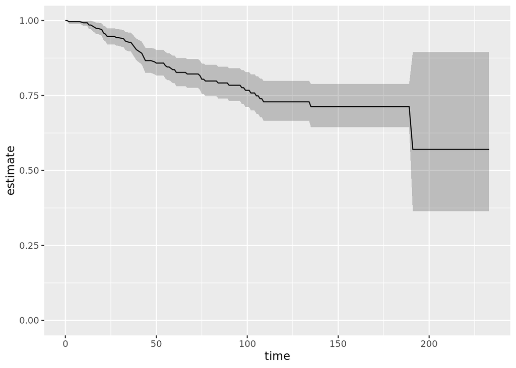

```r
# Overall curve
ggplot(tidy(KM_all), aes(time, estimate)) + geom_line() +
    geom_ribbon(aes(ymin=conf.low, ymax=conf.high), alpha=.25)+
  ylim(0,1)
```

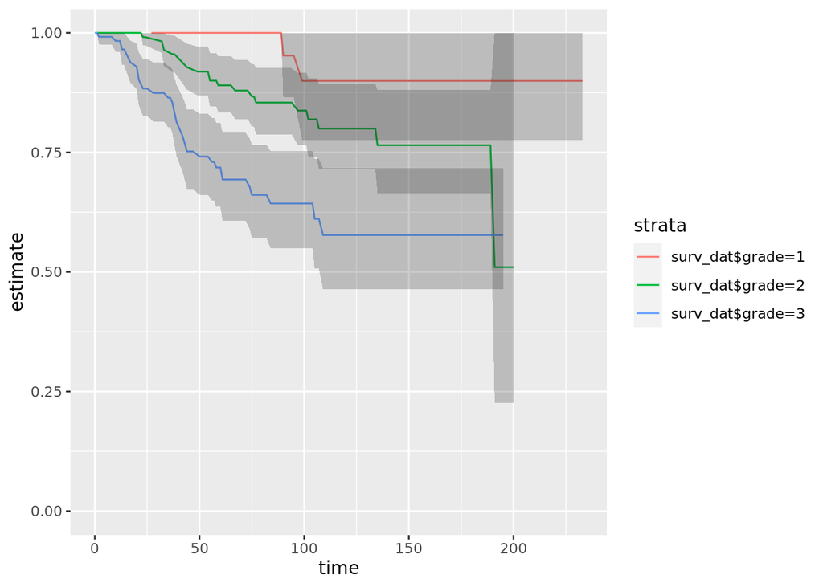

```r
# Grade groups
ggplot(tidy(KM_groups), aes(time, estimate, group = strata)) +
    geom_line(aes(color = strata)) +
    geom_ribbon(aes(ymin = conf.low, ymax = conf.high), alpha = .25)+
  ylim(0,1)
```